# YEG School Placement

Alexander Ondrus

2/24/2020

## Idea/Background

The placement of schools and the programming offered at those schools has long been a subject of much public interest. The issue frequently makes the news (e.g. [here](https://edmontonjournal.com/news/local-news/summerside-parents-say-theyve-been-blindsided-by-proposed-school-boundary-changes)) and the tension is most frequently “Are the kids in the same place as the schools?” Here, I attempt to answer that question in multiple ways. To make things simpler, I restrict my questions to elementary schools (or schools that include elementary schools) and kids under the age of 10 (the census data is in 5 year increments).

## Data

All data is taken from the City of Edmonton Open Data Catalogue. I use the following sources:

- [2019 Census - Population by Age Range (Neighbourhood/Ward)](https://data.edmonton.ca/Census/2019-Census-Population-by-Age-Range-Neighbourhood-/a6zx-dzqn)
- [Edmonton Public Schools (2019)](https://data.edmonton.ca/Schools/Edmonton-Public-Schools-2019-/nk6t-8jsz)
- [Edmonton Catholic Schools (2017-2018)](https://data.edmonton.ca/Schools/Edmonton-Catholic-Schools-2017-2018-/u2mw-7vq5)
- [City of Edmonton - Neighbourhoods (Centroid Point)](https://data.edmonton.ca/City-Administration/City-of-Edmonton-Neighbourhoods-Centroid-Point-/3b6m-fezs/data)
- [City of Edmonton : Neighbourhood Boundaries](https://data.edmonton.ca/Geospatial-Boundaries/City-of-Edmonton-Neighbourhood-Boundaries/jfvj-x253)

```r
epsb <- read_csv("https://data.edmonton.ca/resource/nk6t-8jsz.csv")
ed_catholic <- read_csv("https://data.edmonton.ca/resource/u2mw-7vq5.csv")
nbhd_centroids <- read_csv("https://data.edmonton.ca/resource/3b6m-fezs.csv")
nbhd_bounds <- readOGR("City of Edmonton _ Neighbourhood Boundaries/geo_export_7f6429b0-6d5d-438c-b1ec-c479e30f903a.shp")
nbhd_ages <- read_csv("2019_Census_-_Population_by_Age_Range__Neighbourhood_Ward_.csv") %>%
  select(`Neighbourhood Name`, `Age Range`, `Population`)
colnames(nbhd_ages) <- c("Neighbourhood", "Age", "Population")
```

## Processing & Merging

First, I find the number of kids under 10 in each neighbourhood from the City’s census data.

```r
nbhd_kids <- spread(nbhd_ages,
                    key = "Age",
                    value = "Population") %>%
  mutate(Kids_U10 = `0-4`+`5-9`) %>%
  select(Neighbourhood, Kids_U10)
```

Next, I combine the EPSB and Catholic schools and add a column for the neighbourhood that contains each school. Note again that I only filter for schools that include at least grades K-6.

```r
ed_catholic <- select(ed_catholic, school_name, grade_level, grades_offered, location) %>%
  separate(location, c("latitude", "longitude"), sep = ",")

ed_catholic$latitude <- gsub("(", " ", ed_catholic$latitude, fixed = TRUE) %>% trimws() %>% as.numeric()
ed_catholic$longitude <- gsub(")", " ", ed_catholic$longitude, fixed = TRUE) %>% trimws() %>% as.numeric()

ed_catholic <- filter(ed_catholic,
                      str_detect(grade_level, "Elementary")) %>%
  select(school_name, latitude, longitude)

epsb <- filter(epsb, str_detect(grades, "K")) %>%
  select(school_name, point_y, point_x)

colnames(epsb) <- c("school_name", "latitude", "longitude")

epsb$board <- "EPSB"
ed_catholic$board <- "Catholic"

schools <- rbind(epsb, ed_catholic)

sp_schools <- schools
coordinates(sp_schools) <- c("longitude", "latitude")
proj4string(sp_schools) <- proj4string(nbhd_bounds)

school_nbhd <- over(sp_schools, as(nbhd_bounds, "SpatialPolygons"))
schools$Neighbourhood <- nbhd_bounds$name[school_nbhd]
```

Now I start aggregating the following data into a single dataframe that I call `neighbourhoods`, containing the following columns:

- Neighbourhood (names with mixed case)
- area_sq_km
- latitude (of centroid)
- longitude (of centroid)
- num_schools (number of schools in the neighbourhood)
- kids_U10
- kids_U10_binned (for choropleths)
- km_from_centre (radius from City Centre)
- nearest_school
- km_to_nearest_school

I start using the `nbhd_centroids` data frame

```r
neighbourhoods <- select(nbhd_centroids, name_mixed, area_sq_km, latitude, longitude) %>%
  rename(Neighbourhood = name_mixed)

num_schools <- table(schools$Neighbourhood) %>%
  data.frame() %>%
  rename(Neighbourhood = Var1,
         num_schools = Freq)

neighbourhoods <- left_join(neighbourhoods, num_schools, by = "Neighbourhood") %>%
  left_join(nbhd_kids, by = "Neighbourhood") %>%
  filter(!is.na(Kids_U10))

neighbourhoods$Kids_U10_binned <- cut(neighbourhoods$Kids_U10,
                                      breaks = c(-Inf, 165, 285, 450, Inf),
                                      labels = c("< 165", "165 - 285", "286 - 450", "> 450"),
                                      ordered_result = TRUE)

city_centre <- c(-113.4934, 53.5442)

nbhd_longlat <- as.matrix(neighbourhoods[, c("longitude","latitude")])
rownames(nbhd_longlat) <- neighbourhoods$Neighbourhood

neighbourhoods$km_from_centre <- distVincentyEllipsoid(nbhd_longlat, city_centre)/1000
```

I define a new function to return the nearest school and the distance to the nearest school for any point in the city.

```r
nearest_school_function <- function(long, lat){
  given_point <- c(long,lat)

  schools_long_lat <- select(schools, longitude, latitude) %>% as.matrix()

  distances <- distVincentyEllipsoid(schools_long_lat, given_point) /1000
  min_distance_index <- which(distances == min(distances))

  min_distance <- distances[min_distance_index]
  closest_school <- schools$school_name[min_distance_index]

  return(c(min_distance, closest_school))
}
```

With this function, I can add the remaining columns required above.

```r
nbhd_closest_schools <- mapply(nearest_school_function,
                               neighbourhoods$longitude,
                               neighbourhoods$latitude) %>%
  t() %>% as.data.frame() %>%
  rename(km_to_nearest_school = V1, nearest_school = V2)
neighbourhoods <- cbind(neighbourhoods, nbhd_closest_schools)
neighbourhoods$km_to_nearest_school <- as.numeric(levels(neighbourhoods$km_to_nearest_school))[neighbourhoods$km_to_nearest_school]
neighbourhoods_w_kids <- filter(neighbourhoods, Kids_U10 > 10)
```

This gives the data frame as listed above:

```r
display_table <- head(neighbourhoods)
colnames(display_table) <- c("Neighbourhood", "Area", "latitude", "longitude", "Number\nof Schools",
                             "Kids\nUnder 10", "Kids Under\n10 (binned)", "km from City\nCentre",
                             "km from\nnearest school", "Nearest\nSchool")
kable(display_table, digits = 2) %>% kable_styling()
```

| Neighbourhood | Area | latitude | longitude | Number of Schools | Kids Under 10 | Kids Under 10 (binned) | km from City Centre | km from nearest school | Nearest School |
| --- | --- | --- | --- | --- | --- | --- | --- | --- | --- |
| Kinglet Gardens | 2.64 | 53.58 | -113.70 | 0 | 4 | < 165 | 14.27 | 4.57 | David Thomas King School |
| Anthony Henday Big Lake | 3.22 | 53.59 | -113.65 | 0 | 0 | < 165 | 11.55 | 5.35 | Mayfield School |
| Mill Creek Ravine South | 0.76 | 53.51 | -113.46 | 0 | 0 | < 165 | 4.48 | 0.80 | Donnan School |
| Anthony Henday Rampart | 3.15 | 53.63 | -113.58 | 0 | 0 | < 165 | 10.78 | 1.34 | Elizabeth Finch School |
| Hagmann Estate Industrial | 0.53 | 53.58 | -113.54 | 0 | 0 | < 165 | 5.43 | 0.51 | Prince Charles School |
| Ambleside | 3.14 | 53.43 | -113.60 | 1 | 1028 | > 450 | 14.51 | 0.40 | Dr. Margaret-Ann Armour School |

## Visualizing the Placement of Schools

### Kids in Neighbourhoods Without Schools

The first way of looking at this question is to ask: how many children under the age of 10 live in a neighbourhood which does not contain a school? How many live in neighbourhoods with one school? Two? Three?

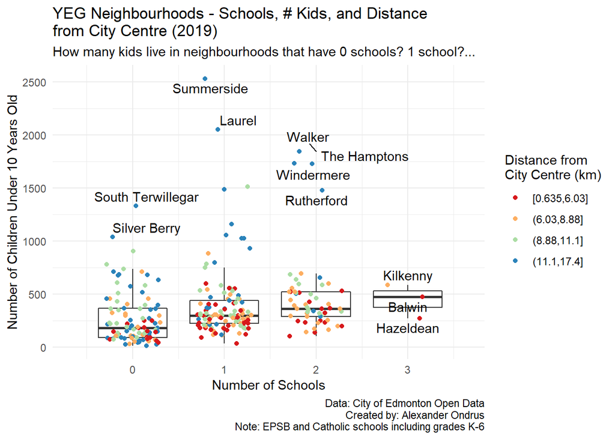

```r
plot1_data <- filter(neighbourhoods, Kids_U10 > 10)
plot1_data$km_from_centre <- cut_number(plot1_data$km_from_centre,
                                                   n = 4,
                                                   ordered_result = TRUE)
plot1_data$labels <- plot1_data$Neighbourhood
plot1_data$labels[which(!(plot1_data$labels %in%
                                       c("Walker", "Summerside", "Laurel", "Balwin",
                                         "Kilkenny", "Hazeldean", "Silver Berry",
                                         "South Terwillegar", "Windermere", "The Hamptons",
                                         "Rutherford")))] <- ""

p1 <- ggplot(plot1_data, aes(x = num_schools,
                                 y = Kids_U10,
                                 group = num_schools)) +
  geom_boxplot(outlier.alpha = 0) +
  geom_point(position = position_jitterdodge(jitter.width = 1.8),
             aes(colour = km_from_centre)) +
  scale_color_brewer(palette = "Spectral") +
  labs(title = "YEG Neighbourhoods - Schools, # Kids, and Distance\nfrom City Centre (2019)",
       subtitle = "How many kids live in neighbourhoods that have 0 schools? 1 school?...",
       x = "Number of Schools",
       y = "Number of Children Under 10 Years Old",
       colour = "Distance from\nCity Centre (km)",
       caption = "Data: City of Edmonton Open Data\nCreated by: Alexander Ondrus\nNote: EPSB and Catholic schools including grades K-6") +
  theme_minimal() +
  geom_text_repel(aes(label = labels))
plot(p1)
```

### Distance to Nearest School

Next, for each neighbourhood, I look at the number of kids under 10 years old and the distance to the nearest elementary school.

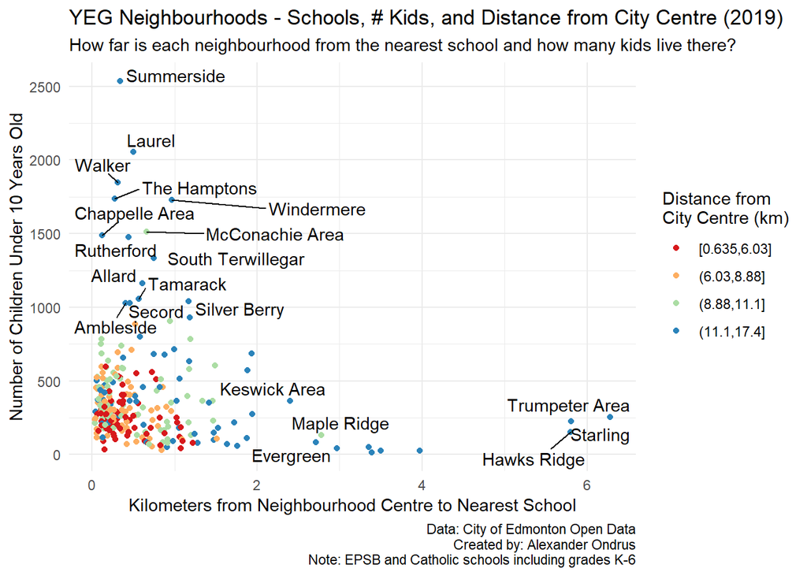

```r
plot2_data <- plot1_data
plot2_data$labels <- plot2_data$Neighbourhood
plot2_data$labels[which((plot2_data$km_to_nearest_school < 2) &
                          (plot2_data$Kids_U10 < 1000) |
                          (plot2_data$Kids_U10 < 50))] <- ""

p2 <- ggplot(plot2_data, aes(x = km_to_nearest_school,
                             y = Kids_U10)) +
  geom_point(aes(colour = km_from_centre)) +
    scale_color_brewer(palette = "Spectral") +
  geom_text_repel(aes(label = labels), force = 5) +
  labs(title = "YEG Neighbourhoods - Schools, # Kids, and Distance from City Centre (2019)",
       subtitle = "How far is each neighbourhood from the nearest school and how many kids live there?",
       x = "Kilometers from Neighbourhood Centre to Nearest School",
       y = "Number of Children Under 10 Years Old",
       colour = "Distance from\nCity Centre (km)",
       caption = "Data: City of Edmonton Open Data\nCreated by: Alexander Ondrus\nNote: EPSB and Catholic schools including grades K-6") +
  theme_minimal()
plot(p2)
```

In order to overcome the over-plotting issue, we can animate this to look at the neighbourhoods that are closest to each school one-by-one.

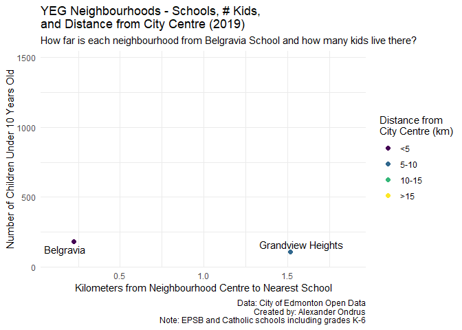

```r
plot3_data <- neighbourhoods %>%
  filter(nearest_school %in% c("Bishop David Motiuk",
                              "Johnny Bright School",
                              "Holyrood School",
                              "York School",
                              "Belgravia School"),
         Kids_U10 > 10)
plot3_data$labels <- plot3_data$Neighbourhood
plot3_data$nearest_school <- droplevels(plot3_data$nearest_school)

plot3_data$km_from_centre_binned <- cut(plot3_data$km_from_centre,
                                        breaks = c(0, 5, 10, 15, Inf),
                                        labels = c("<5","5-10","10-15",">15"),
                                        ordered_result = TRUE)

p3 <- ggplot(plot3_data, aes(x = km_to_nearest_school,
                             y = Kids_U10,
                             group = nearest_school)) +
  geom_point(aes(colour = km_from_centre_binned),
             size = 2) +
  geom_text_repel(aes(label = labels), seed = 1) +
  transition_states(nearest_school) +
  labs(title = "YEG Neighbourhoods - Schools, # Kids,\nand Distance from City Centre (2019)",
       subtitle = "How far is each neighbourhood from {closest_state} and how many kids live there?",
       x = "Kilometers from Neighbourhood Centre to Nearest School",
       y = "Number of Children Under 10 Years Old",
       colour = "Distance from\nCity Centre (km)",
       caption = "Data: City of Edmonton Open Data\nCreated by: Alexander Ondrus\nNote: EPSB and Catholic schools including grades K-6") +
  theme_minimal() +
  enter_fade() +
  exit_shrink()
animate(p3, nframes = 200, duration = 15)
```

To show how I picked the schools in the animation above, I draw a map of the neighbourhoods in Edmonton with the schools labelled, the neighbourhoods coloured by the number of kids under 10.

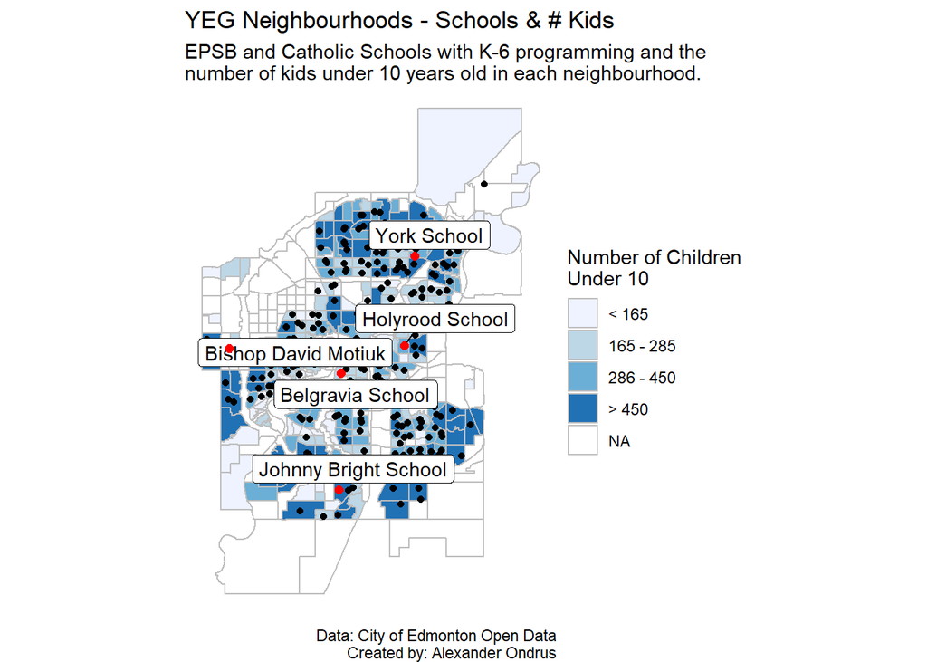

```r
nbhd_bounds_fortified <- fortify(nbhd_bounds, region = "name")
plot4_data <- select(neighbourhoods_w_kids, Neighbourhood, Kids_U10_binned)
nbhd_bounds_fortified <- left_join(nbhd_bounds_fortified, plot4_data, by = c("id"="Neighbourhood"))
school_labels <- filter(schools, school_name %in% c("Bishop David Motiuk",
                              "Johnny Bright School",
                              "Holyrood School",
                              "York School",
                              "Belgravia School"))

p4 <- ggplot(nbhd_bounds_fortified, aes(x = long, y = lat)) +
  geom_polygon(colour = "grey",
               aes(group = group,
               fill = Kids_U10_binned)) +
  coord_map() +
  theme_void() +
  scale_fill_brewer() +
  geom_point(data = schools,
             aes(x = longitude,
                 y = latitude)) +
  geom_label_repel(data = school_labels,
                  aes(x = longitude,
                      y = latitude,
                      label = school_name)) +
  geom_point(data = school_labels,
             aes(x = longitude,
                 y = latitude),
             colour = "red",
             size = 2) +
  labs(title = "YEG Neighbourhoods - Schools & # Kids",
       subtitle = "EPSB and Catholic Schools with K-6 programming and the\nnumber of kids under 10 years old in each neighbourhood.",
       fill = "Number of Children\nUnder 10",
       caption = "Data: City of Edmonton Open Data\nCreated by: Alexander Ondrus")
plot(p4)
```